# STAT 385: Homework 02

Ha Khanh Nguyen - Spring 2020, UIUC

Due: Friday, February 14, 11:59 PM

## Instructions

- Maximum total number of points for this homework is 50.
- Download the R script template and write your R code in this file for submission.
- Rename the R script as `hw02-your-name.R`. For example, my R script file will be `hw02-ha-nguyen.R`.
- Make sure to include your name in the R script file.
- Submit the R script (`.R`) file to Compass by **11:59 PM on Friday, 02/14/2020**. You can submit as many times as needed up until the deadline. **The latest version submitted will be graded**.

## Exercise 1: French Roulette

- Don’t worry! You’re on the right homework! This is Homework 02. We just really like playing roulette.

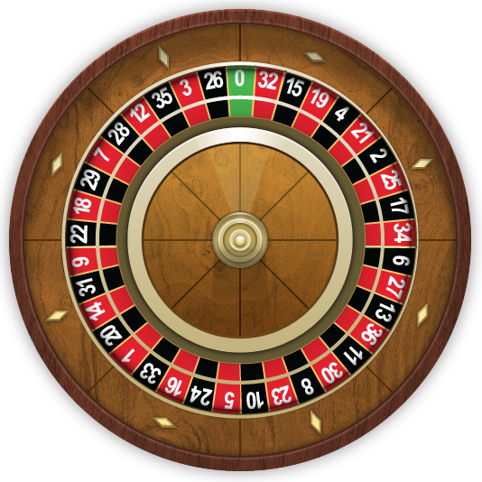

- A French roulette has:
- **37 colored and numbered pockets** on the wheel.
- 0 is green.
- In number ranges from 1 to 10 and 19 to 28:
  - Odd numbers are red.
  - Even numbers are black.
- In ranges from 11 to 18 and 29 to 36:
  - Odd numbers are black.
  - Even numbers are red.

**TASKS**:

- **(a)** (3 points) Read the data in `roulette.csv` file from the URL: https://nkha149.github.io/stat385-sp2020/files/data/roulette.csv and stores the data as a data frame named `wheel`.
- Your data frame should look like this if you correctly import the data:

```r
# import the data
wheel <-read.csv("https://nkha149.github.io/stat385-sp2020/files/data/roulette.csv")
wheel
```

```
##    number color
## 1       0 green
## 2       1   red
## 3       2 black
## 4       3   red
## 5       4 black
## 6       5   red
## 7       6 black
## 8       7   red
## 9       8 black
## 10      9   red
## 11     10 black
## 12     11 black
## 13     12   red
## 14     13 black
```

[output cut: 23 more lines]

- **(b)** (12 points) Write an R function named `roulette()` that simulate a roulette, that is it has:
- **Input**: 2 arguments `bet` and `amount`
  - `bet`: argument that takes one of the following options:
  - `low`(1-18) or `high` (19-36): A bet that the number will be in the chosen range.
  - `red` or `black`: A bet that the number will be the chosen color.
  - `even` or `odd`: A bet that the number will be of the chosen type.
  - `first` or `second` or `third`: A bet that the number will be in the chosen dozen: first (1-12), second (13-24), or third (25-36).
  - any number from 0 to 36.
  - `amount`: amount in dollars that you want to bet on. The default value for `amount` is `1`.
- **Output**:
  - The amount of money you gain/lose after the bet.
  - `-amount` if you lose the bet.
  - The amount of money win is calculated following the table below.
  - Make sure to include the `$` dollar sign.

| Bet Name | Winning spaces | Payout |
| --- | --- | --- |
| Straight up (a single number) | Any single number | 36 to 1 |
| Low (1 to 18) | 1, 2, 3, …, 18 | 1 to 1 |
| High (19 to 36) | 19, 20, 21, …, 36 | 1 to 1 |
| Red | 1, 3, 5, 7, 9, 12, 14, 16, 18, 19, 21, 23, 25, 27, 30, 32, 34, 36 | 1 to 1 |
| Black | 2, 4, 6, 8, 10, 11, 13, 15, 17, 20, 22, 24, 26, 28, 29, 31, 33, 35 | 1 to 1 |
| Odd | 1, 3, 5, …, 35 | 1 to 1 |
| Even | 2, 4, 6, …, 36 | 1 to 1 |
| 1st dozen | 1 through 12 | 2 to 1 |
| 2nd dozen | 13 through 24 | 2 to 1 |
| 3rd dozen | 25 through 36 | 2 to 1 |

- Examples:
  - Ha bets on `red` with $10. If she wins, her gain amount will be $10 (1 to 1 payout rate).
  - Ha bets on `5` with $1. If she wins, her gain amount will be $36 (36 to 1 payout rate).
  - Ha bets on `low` with $15. If she loses, her lose amount will be -$15. :(

```r
# your function
roulette<-function (bet,amount=1){
  a<-sample(0:36,size=1)
  low<-(1:18)
  high<-(19:36)
  first<-(1:12)
  second<-(13:24)
  third<-(25:36)
  red<-(wheel[wheel$color=="red", ]$number)
  black<-(wheel$color=="black")
  single<-(0:36)
  even<-wheel[c(TRUE,FALSE),]$number
  odd<-wheel[c(FALSE,TRUE),]$number

  money <- 0

  if (bet == "low"){
    if (a %in% low) {
      money <- amount
    } else{
      money <- - amount
    }
  } else if (bet == "high"){
    if (a %in% high) {
      money <- amount
    } else{
      money <- - amount
    }
  } else if (bet == "first"){
    if (a %in% first) {
      money <- 2*amount
    } else{
      money <- -2*amount
    }
  } else if (bet == "second"){
    if (a %in% second) {
      money <- 2*amount
    } else{
      money <- -2*amount
    }
  } else if (bet == "third"){
    if (a %in% third) {
      money <- 2*amount
    } else{
      money <- -2*amount
    }
  } else if (bet == "red"){
    if (a %in% red) {
      money <- amount
    } else{
      money <- - amount
    }
  } else if (bet == "balck"){
    if (a %in% balck) {
      money <- amount
    } else{
      money <- - amount
    }
  } else if (bet == "odd"){
    if (a %in% odd) {
      money <- amount
    } else{
      money <- - amount
    }
  } else if (bet == "even"){
    if (a %in% even) {
      money <- amount
    } else{
      money <- - amount
    }
  } else if (bet == a){
    money <- 36*amount
  } else{
    money <- - amount
  }
  if(money>=0){cat("$", money, sep = "")}
  else if(money< 0){cat("-$",abs(money), sep="")}
}
```

- Use the following code to test your function. You should get the exact same outputs as shown.
- Remove `eval=FALSE` in each chunk.

```r
set.seed(385)
roulette(bet = "red", amount = 10)
```

```
## $10
```

```r
set.seed(385)
roulette(bet = "first", amount = 15)
```

```
## $30
```

```r
set.seed(385)
roulette(bet = "odd", amount = 20)
```

```
## $20
```

```r
set.seed(385)
roulette(bet = 9, amount = 10)
```

```
## -$10
```

```r
set.seed(385)
roulette(bet = 5)
```

```
## $36
```

## Exercise 2: Simulations and Graphing

- **(a)** (5 points) Modify function `roulette()` so that now it can only print out the amount of money lose/gain (e.g., 10, -10, 15, etc.) **without the dollar sign $**. Name this new function `roulette2()`.

```r
# your roulette2 function
roulette2<-function (bet,amount=1){
  a<-sample(0:36,size=1)
  low<-(1:18)
  high<-(19:36)
  first<-(1:12)
  second<-(13:24)
  third<-(25:36)
  red<-(wheel[wheel$color=="red", ]$number)
  black<-(wheel$color=="black")
  single<-(0:36)
  even<-wheel[c(TRUE,FALSE),]$number
  odd<-wheel[c(FALSE,TRUE),]$number

  money <- 0

  if (bet == "low"){
    if (a %in% low) {
      money <- amount
    } else{
      money <- - amount
    }

  } else if (bet == "high"){
    if (a %in% high) {
      money <- amount
    } else{
      money <- - amount
    }
  } else if (bet == "first"){
    if (a %in% first) {
      money <- 2*amount
    } else{
      money <- -2*amount
    }
  } else if (bet == "second"){
    if (a %in% second) {
      money <- 2*amount
    } else{
      money <- -2*amount
    }
  } else if (bet == "third"){
    if (a %in% third) {
      money <- 2*amount
    } else{
      money <- -2*amount
    }
  } else if (bet == "red"){
    if (a %in% red) {
      money <- amount
    } else{
      money <- - amount
    }
  } else if (bet == "balck"){
    if (a %in% balck) {
      money <- amount
    } else{
      money <- - amount
    }
  } else if (bet == "odd"){
    if (a %in% odd) {
      money <- amount
    } else{
      money <- - amount
    }
  } else if (bet == "even"){
    if (a %in% even) {
      money <- amount
    } else{
      money <- - amount
    }
  } else if (bet == a){
    money <- 36*amount
  } else{
    money <- - amount
  }
  money
}
```

- Use the following code to test your function. You should get the exact same outputs as shown.
- Remove `eval=FALSE` in each chunk.

```r
set.seed(385)
roulette2(bet = "red", amount = 10)
```

```
## [1] 10
```

```r
set.seed(385)
roulette2(bet = "first", amount = 15)
```

```
## [1] 30
```

```r
set.seed(385)
roulette2(bet = "odd", amount = 20)
```

```
## [1] 20
```

```r
set.seed(385)
roulette2(bet = 9, amount = 10)
```

```
## [1] -10
```

```r
set.seed(385)
roulette2(bet = 5)
```

```
## [1] 36
```

- **(b)** (5 points) We want to estimate the **probability of winning if we keep betting on `red`**. To do that, we use simulation studies, that is running the `roulette2()` function many many times and record the number of times we win (not have a negative total amount at the end of the game). The number of simulations $n$ is 5000.

```r
set.seed(385)
set.seed(385)
results <- replicate(roulette2(bet = "red"), n = 5000)
mean(results > 0)
```

```
## [1] 0.4862
```

- **(c)** (5 points) Similarly, we want estimate the **probability of winning if we keep betting on the `first` dozen**. The number of simulations $n$ is 5000.

```r
set.seed(385)
set.seed(385)
results <- replicate(roulette2(bet = "first"), n = 5000)
mean(results > 0)
```

```
## [1] 0.3114
```

- **(d)** (5 points) Now, we want to estimate the **expected value of amount of money we will have by the end of the game if we bet on `odd` with $5**. In this example, the number of simulations is 7500.

```r
set.seed(385)
set.seed(385)
results <- replicate(roulette2(bet = "odd", amount = 5), n = 7500)
mean(results)
```

```
## [1] -0.2586667
```

## Exercise 3: Iris Flower Dataset

- **(a)** (5 points) Plot the histogram of the `Sepal.Length` of all three types of the Iris flowers.

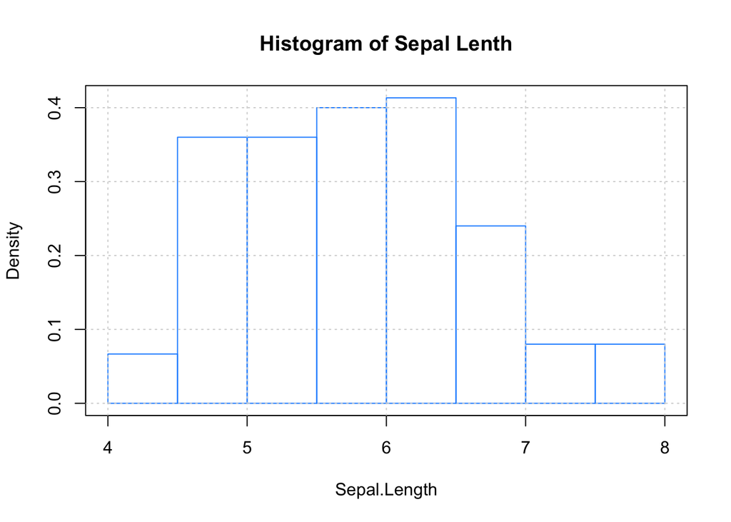

```r
# plot histogram
hist(x=iris$Sepal.Length, main = "Histogram of Sepal Lenth",xlab = "Sepal.Length",
     ylab="Density",probability = TRUE,border  = "dodgerblue")
box()
grid()
```

- **(b)** (5 points) Plot a scatterplot of the `Sepal.Length` (x-axis) and the `Sepal.Width` (y-axis) of all three types of the Iris flowers.

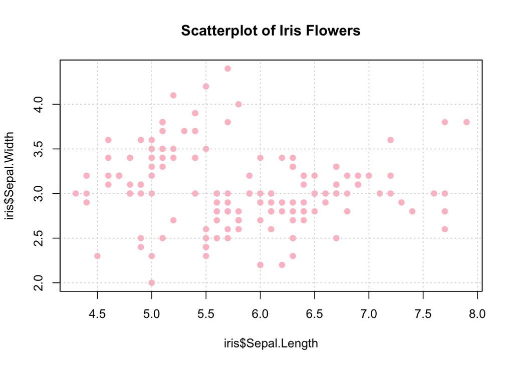

```r
# plot scatterplot
plot(x=iris$Sepal.Length, y = iris$Sepal.Width,
     main = "Scatterplot of Iris Flowers",pch=19,col="pink")
grid()
box()
```

- **(c)** (5 points) Same as part (b) but now color the points depending on their `Species`. That is,
- If the flower is `setosa`, color of the point is `green` (or other color).
- If the flower is `versicolor`, the color of the point is `red` (or other color).
- If the flower is `virginica`, the color of the point is `blue` (or other color).
- Your plot should look something like this:

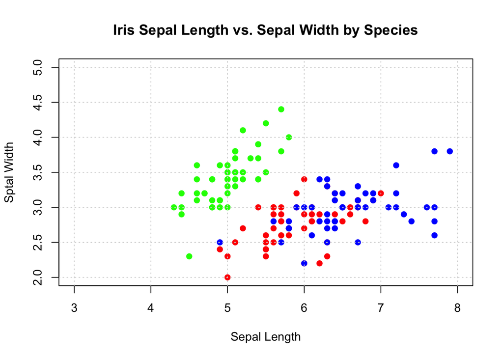

```r
# plot scatterplot with colors
setosa <- iris[iris$Species=='setosa',]
versicolor <- iris[iris$Species=='versicolor',]
virginica <- iris[iris$Species=='virginica',]
plot(setosa$Sepal.Length, setosa$Sepal.Width, pch=19, col='green', xlim=c(3,8),
     ylim=c(2,5), xlab = "Sepal Length", ylab = "Sptal Width", main="Iris Sepal Length vs. Sepal Width by Species")
points(versicolor$Sepal.Length, versicolor$Sepal.Width, pch=19, col='red')
points(virginica$Sepal.Length, virginica$Sepal.Width, pch=19, col='blue')
grid()
```